# Decorrelation-Based Benchmarking: NHNES

Jose Tamez

2024-03-07

# 1 Effect of UPSTM-Based Decorrelation on Regression Fit

### 1.0.1 Loading the libraries

```r
library("FRESA.CAD")
library(readxl)
library(igraph)
library(umap)
library(tsne)
library(entropy)

op <- par(no.readonly = TRUE)
pander::panderOptions('digits', 3)
pander::panderOptions('table.split.table', 400)
pander::panderOptions('keep.trailing.zeros',TRUE)
```

## 1.1 Material

Data source:

https://www.kaggle.com/datasets/cdc/national-health-and-nutrition-examination-survey?select=labs.csv

Details:

https://www.cdc.gov/Nchs/Nhanes/about_nhanes.htm

```r
demographic <- as.data.frame(read_excel("~/GitHub/LatentBiomarkers/Data/NHNES/demographic.xlsx"))
demographiDesc <- as.data.frame(read_excel("~/GitHub/LatentBiomarkers/Data/NHNES/demographic.xlsx",sheet = "Sheet1"))

rownames(demographic) <- demographic$SEQN
demographic$SEQN <- NULL

vartokeep <- demographiDesc[demographiDesc$Keep=="Yes",1]
demographic <- demographic[,vartokeep]

keepColumn <- apply(!is.na(demographic),2,sum)/nrow(demographic) > 0.75
demographic <- demographic[,keepColumn]
demographic <- demographic[complete.cases(demographic),]

## Examination data
examination <- as.data.frame(read_excel("~/GitHub/LatentBiomarkers/Data/NHNES/examination.xlsx"))
examinationDesc <- as.data.frame(read_excel("~/GitHub/LatentBiomarkers/Data/NHNES/examination.xlsx",sheet = "Sheet1"))
rownames(examination) <- examination$SEQN
examination$SEQN <- NULL

bpresDI <- examination[,c("BPXDI1","BPXDI2","BPXDI3","BPXDI4")]
examination[,c("BPXDI1","BPXDI2","BPXDI3","BPXDI4")] <- NULL
bpresDIM <- apply(bpresDI,1,mean,na.rm=TRUE)
summary(bpresDIM)
```

```
#>    Min. 1st Qu.  Median    Mean 3rd Qu.    Max.    NA's
#>    0.00   58.00   66.67   65.44   74.67  128.00    2282
```

```r
bpresSY <- examination[,c("BPXSY1","BPXSY2","BPXSY3","BPXSY4")]
examination[,c("BPXSY1","BPXSY2","BPXSY3","BPXSY4")] <- NULL
bpresSYM <- apply(bpresSY,1,mean,na.rm=TRUE)
summary(bpresSYM)
```

```
#>    Min. 1st Qu.  Median    Mean 3rd Qu.    Max.    NA's
#>   64.67  106.00  115.33  118.31  128.00  228.67    2282
```

```r
examination$PEASCST1 <- NULL
examination$bpresDIM <- bpresDIM
examination$bpresSYM <- bpresSYM

keepColumn <- apply(!is.na(examination),2,sum)/nrow(examination) > 0.75
examination <- examination[,keepColumn]
keepColumnVar <- !is.na(apply(examination,2,var,na.rm = TRUE))
examination <- examination[,keepColumnVar]
examination <- examination[complete.cases(examination),]
examination <- examination[examination$bpresDIM>0,]



## questionnaire data
questionnaire <- as.data.frame(read_excel("~/GitHub/LatentBiomarkers/Data/NHNES/questionnaire.xlsx"))
questionnaireDesc <- as.data.frame(read_excel("~/GitHub/LatentBiomarkers/Data/NHNES/questionnaire.xlsx",sheet = "Sheet1"))
rownames(questionnaire) <- questionnaire$SEQN
questionnaire$SEQN <- NULL
table(questionnaire$MCQ010)
```

```
#>
#>    1    2    7    9
#> 1538 8222    1    8
```

```r
#keepColumn <- apply(!is.na(questionnaire),2,sum)/nrow(questionnaire) > 0.85
#questionnaire <- questionnaire[,keepColumn]
#keepColumnVar <- !is.na(apply(questionnaire,2,var,na.rm = TRUE))
#questionnaire <- questionnaire[,keepColumnVar]
#questionnaire <- questionnaire[complete.cases(questionnaire),]
#keeprow <- apply(questionnaire,2,max) < 9000
#questionnaire <- questionnaire[keeprow,]
#table(questionnaire$MCQ010)

## Diabetes
Diabetes <- questionnaire$MCQ010
names(Diabetes) <- rownames(questionnaire)
Diabetes <- Diabetes[!is.na(Diabetes)]
Diabetes <- Diabetes[Diabetes<3]
table(Diabetes)
```

```
#> Diabetes
#>    1    2
#> 1538 8222
```

```r
## Depression
depression <- questionnaire[,c("DPQ010","DPQ020","DPQ030","DPQ040","DPQ050","DPQ060","DPQ070","DPQ080","DPQ090")]
depression[depression>5] <- NA
depressionTot <- apply(depression,1,sum,na.rm=TRUE)
donnow <- apply(is.na(depression),1,sum) == 9
depressionTot <- depressionTot[!donnow]
table(depressionTot)
```

```
#> depressionTot
#>    0    1    2    3    4    5    6    7    8    9   10   11   12   13   14   15
#> 1718  852  631  470  360  233  214  162  137  104   90   66   53   51   57   31
#>   16   17   18   19   20   21   22   23   24   25   27
#>   39   26   27   19   16   12   11    4    7    4    3
```

```r
## The labs data
labs <- as.data.frame(read_excel("~/GitHub/LatentBiomarkers/Data/NHNES/labs.xlsx"))
labsDesc <- as.data.frame(read_excel("~/GitHub/LatentBiomarkers/Data/NHNES/labs.xlsx",sheet = "Sheet1"))

rownames(labs) <- labs$SEQN
labs$SEQN <- NULL

keepColumn <- apply(!is.na(labs),2,sum)/nrow(labs) > 0.75
labs <- labs[,keepColumn]
keepColumnVar <- !is.na(apply(labs,2,var,na.rm = TRUE))
labs <- labs[,keepColumnVar]
labs <- labs[complete.cases(labs),]

includeIDS <- rownames(labs)[rownames(labs) %in% rownames(examination)]
includeIDS <- includeIDS[includeIDS %in% rownames(demographic)]

includeIDS <- includeIDS[includeIDS %in% names(Diabetes)]

Diab <- Diabetes[includeIDS]
table(Diab)
```

```
#> Diab
#>    1    2
#>  992 5006
```

```r
NHNES <- cbind(demographic[includeIDS,],examination[includeIDS,],labs[includeIDS,])
NHNES$Diab <- Diab

table(NHNES$Diab)
```

```
#>
#>    1    2
#>  992 5006
```

```r
## Only Adults in this experiment
NHNES <- NHNES[NHNES$RIDAGEYR >= 20,]

NHNES$Diab <- 1*(NHNES$Diab == 1)

table(NHNES$Diab)
```

```
#>
#>    0    1
#> 3664  650
```

```r
includeIDS <- rownames(NHNES)
includeIDS <- includeIDS[includeIDS %in% names(depressionTot)]
depressionTot <- depressionTot[includeIDS]
NHNESDep <- cbind(NHNES[includeIDS,],depressionTot)

NHNESDep$depressionTot <- log(NHNESDep$depressionTot+1)

tbdep <- table(NHNESDep$depressionTot)
genderDiab <- NHNESDep[,c("RIAGENDR","Diab")]

isContinuous <- sapply(apply(NHNESDep,2,unique),length) > 4
sum(isContinuous)
```

```
#> [1] 63
```

```r
NHNESDep <- cbind(NHNESDep[,isContinuous],genderDiab)

table(NHNESDep$RIAGENDR)
```

```
#>
#>    1    2
#> 2059 2094
```

```r
colnames(NHNESDep)[sapply(apply(NHNESDep,2,unique),length) < 10]
```

```
#>  [1] "OHX04TC"  "OHX06TC"  "OHX10TC"  "OHX11TC"  "OHX13TC"  "OHX20TC"
#>  [7] "OHX25TC"  "OHX29TC"  "LBDBANO"  "RIAGENDR" "Diab"
```

#### 1.1.0.1 Standarize the names for the reporting

```r
studyName <- "NHNES"
dataframe <- NHNESDep
outcome <- "RIDAGEYR"

thro <- 0.40
cexheat <- 0.35
loops  <- 100
tfrac <- 0.80
```

## 1.2 Generaring the report

### 1.2.1 Libraries

Some libraries

```r
library("pls")
```

### 1.2.2 CV interface

```r
plfit <- function(formula=formula,data=NULL,...)
{
  fitpls <- plsr(formula=formula,data=data,scale =TRUE,...)
  class(fitpls) <- c("TopPLS",class(fitpls))
  return(fitpls)
}

pcrfit <- function(formula=formula,data=NULL,...)
{
  fitpls <- pcr(formula=formula,data=data,scale =TRUE,...)
  class(fitpls) <- c("TopPLS",class(fitpls))
  return(fitpls)
}

cpplsfit <- function(formula=formula,data=NULL,...)
{
  fitpls <- cppls(formula=formula,data=data,scale =TRUE,...)
  class(fitpls) <- c("TopPLS",class(fitpls))
  return(fitpls)
}

predict.TopPLS <- function(object,...)
{
  parameters <- list(...);
    testData <- parameters[[1]];
    class(object) <- class(object)[2]
  pred <- predict(object,newdata=testData)
  return(pred[,1,object$ncomp])
}
```

## 1.3 PLSR vs ILAA

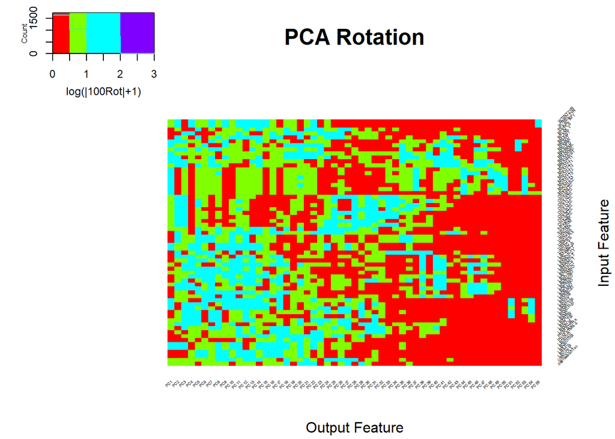

```r
toPCA <- sapply(apply(dataframe,2,unique),length) >= 5 & colnames(dataframe) != outcome

pc <- prcomp(dataframe[,toPCA],center = TRUE,scale. = TRUE,tol=0.01)   #principal components


rotstd <- log10(abs(100*pc$rotation)+1.0)
  gplots::heatmap.2(rotstd,
                    trace = "none",
                    dendrogram="none",
                    breaks=c(0,0.5,1,2,3),
#                    scale="row",
                    mar = c(5,5),
                    col=rainbow(4),
                    main = "PCA Rotation",
                    cexRow = cexheat,
                    cexCol = cexheat,
                    Rowv=FALSE,
                    Colv=FALSE,
                   srtCol=45,
                   srtRow=45,
                    key.title=NA,
                    key.xlab="log(|100Rot|+1)",
                    xlab="Output Feature", ylab="Input Feature")
```

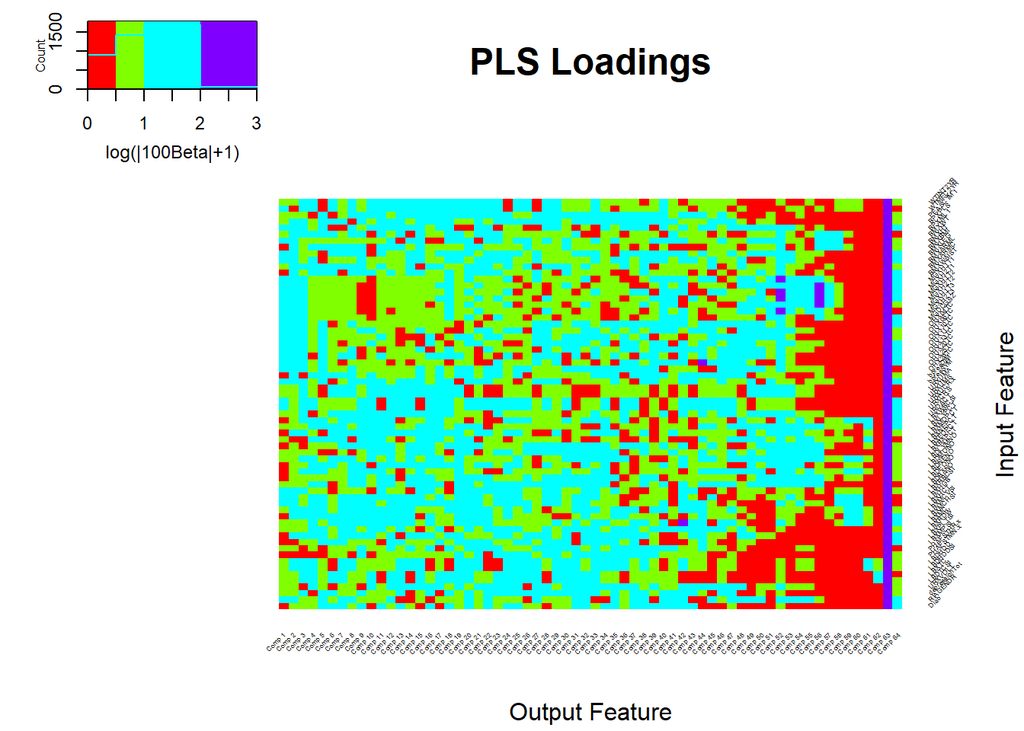

```r
plm <- plsr(formula=formula(paste(outcome,"~.")),data=dataframe,scale =TRUE)

loadadings <- log10(abs(100*plm$loadings) + 1.0)
  gplots::heatmap.2(loadadings,
                    breaks=c(0,0.5,1,2,3),
                    trace = "none",
                    dendrogram="none",
#                    scale="row",
                    mar = c(5,5),
                    col=rainbow(4),
                    main = "PLS Loadings",
                    cexRow = cexheat,
                    cexCol = cexheat,
                    Rowv=FALSE,
                    Colv=FALSE,
                   srtCol=45,
                   srtRow=45,
                    key.title=NA,
                    key.xlab="log(|100Beta|+1)",
                    xlab="Output Feature", ylab="Input Feature")
```

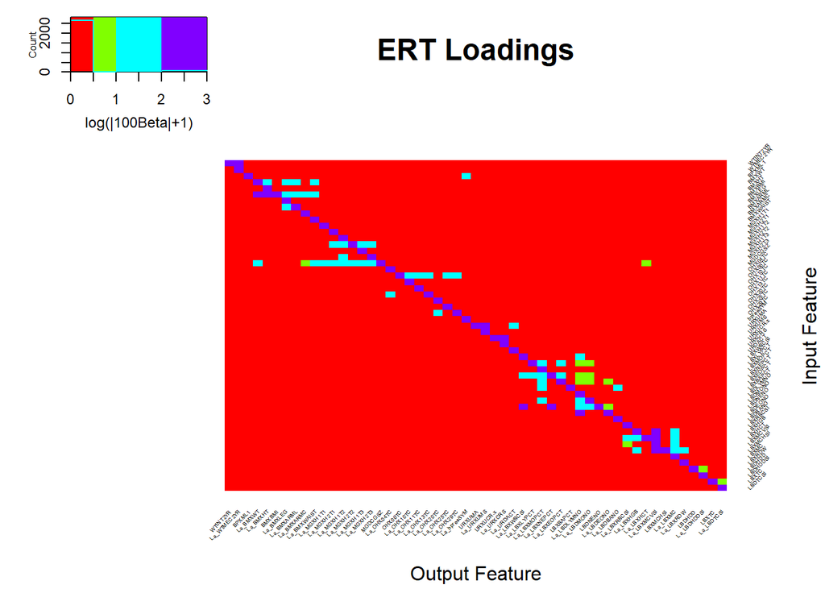

```r
ERTmod <- ILAA(dataframe,Outcome = outcome,thr=thro)

ERT <- log10(abs(100*attr(ERTmod,"UPLTM")) + 1);
  gplots::heatmap.2(ERT,
                    trace = "none",
                    breaks=c(0,0.5,1,2,3),
                    mar = c(5,5),
                    col=rainbow(4),
                    main = "ERT Loadings",
                    cexRow = cexheat,
                    cexCol = cexheat,
                    dendrogram="none",
                    Rowv=FALSE,
                    Colv=FALSE,
                   srtCol=45,
                   srtRow=45,
                    key.title=NA,
                    key.xlab="log(|100Beta|+1)",
                    xlab="Output Feature", ylab="Input Feature")
```

## 1.4 SOTA Comparison to PLS, PC, LASSO, and ENET

### 1.4.1 PLSR

```r
PLScv <- randomCV(dataframe,outcome,plfit,
                        trainFraction = tfrac,
                        repetitions = loops)
```

……….10 Tested: 3689 Avg. Selected: 0 Min Tests: 1 Max Tests: 8 Mean Tests: 2.252643 . MAD: 8.847591

……….20 Tested: 4107 Avg. Selected: 0 Min Tests: 1 Max Tests: 11 Mean Tests: 4.046749 . MAD: 8.830125

……….30 Tested: 4148 Avg. Selected: 0 Min Tests: 1 Max Tests: 14 Mean Tests: 6.010125 . MAD: 8.834998

……….40 Tested: 4153 Avg. Selected: 0 Min Tests: 1 Max Tests: 17 Mean Tests: 8.003853 . MAD: 8.827853

……….50 Tested: 4153 Avg. Selected: 0 Min Tests: 2 Max Tests: 21 Mean Tests: 10.00482 . MAD: 8.826057

……….60 Tested: 4153 Avg. Selected: 0 Min Tests: 3 Max Tests: 24 Mean Tests: 12.00578 . MAD: 8.825194

……….70 Tested: 4153 Avg. Selected: 0 Min Tests: 3 Max Tests: 27 Mean Tests: 14.00674 . MAD: 8.823964

……….80 Tested: 4153 Avg. Selected: 0 Min Tests: 5 Max Tests: 31 Mean Tests: 16.00771 . MAD: 8.822093

……….90 Tested: 4153 Avg. Selected: 0 Min Tests: 5 Max Tests: 33 Mean Tests: 18.00867 . MAD: 8.820267

……….100 Tested: 4153 Avg. Selected: 0 Min Tests: 8 Max Tests: 36 Mean Tests: 20.00963 . MAD: 8.820629

```r
PLSbs <- predictionStats_regression(PLScv$medianTest,"PLS: CV")
```

PLS: CV

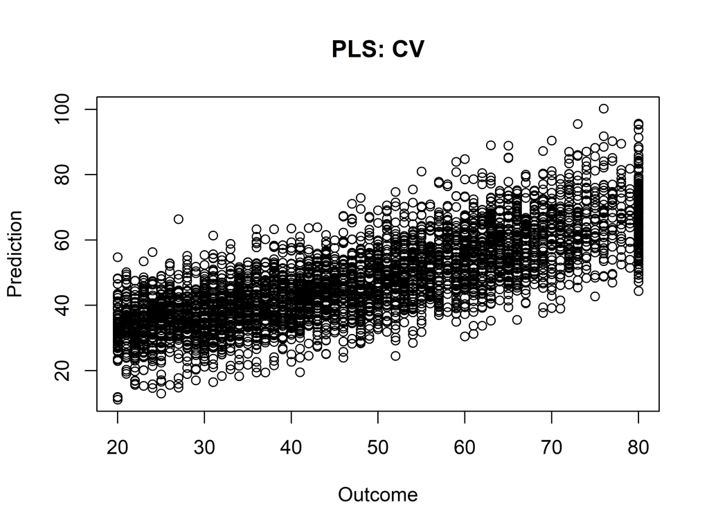

### 1.4.2 PC

```r
PCcv <- randomCV(fittingFunction = pcrfit,
                     trainSampleSets = PLScv$trainSamplesSets
                    )
```

……….10 Tested: 3689 Avg. Selected: 0 Min Tests: 1 Max Tests: 8 Mean Tests: 2.252643 . MAD: 8.848624

……….20 Tested: 4107 Avg. Selected: 0 Min Tests: 1 Max Tests: 11 Mean Tests: 4.046749 . MAD: 8.831868

……….30 Tested: 4148 Avg. Selected: 0 Min Tests: 1 Max Tests: 14 Mean Tests: 6.010125 . MAD: 8.834212

……….40 Tested: 4153 Avg. Selected: 0 Min Tests: 1 Max Tests: 17 Mean Tests: 8.003853 . MAD: 8.831604

……….50 Tested: 4153 Avg. Selected: 0 Min Tests: 2 Max Tests: 21 Mean Tests: 10.00482 . MAD: 8.828019

……….60 Tested: 4153 Avg. Selected: 0 Min Tests: 3 Max Tests: 24 Mean Tests: 12.00578 . MAD: 8.827132

……….70 Tested: 4153 Avg. Selected: 0 Min Tests: 3 Max Tests: 27 Mean Tests: 14.00674 . MAD: 8.823278

……….80 Tested: 4153 Avg. Selected: 0 Min Tests: 5 Max Tests: 31 Mean Tests: 16.00771 . MAD: 8.82164

……….90 Tested: 4153 Avg. Selected: 0 Min Tests: 5 Max Tests: 33 Mean Tests: 18.00867 . MAD: 8.822964

……….100 Tested: 4153 Avg. Selected: 0 Min Tests: 8 Max Tests: 36 Mean Tests: 20.00963 . MAD: 8.822803

```r
PCbs <- predictionStats_regression(PCcv$medianTest,"PCR: CV")
```

PCR: CV

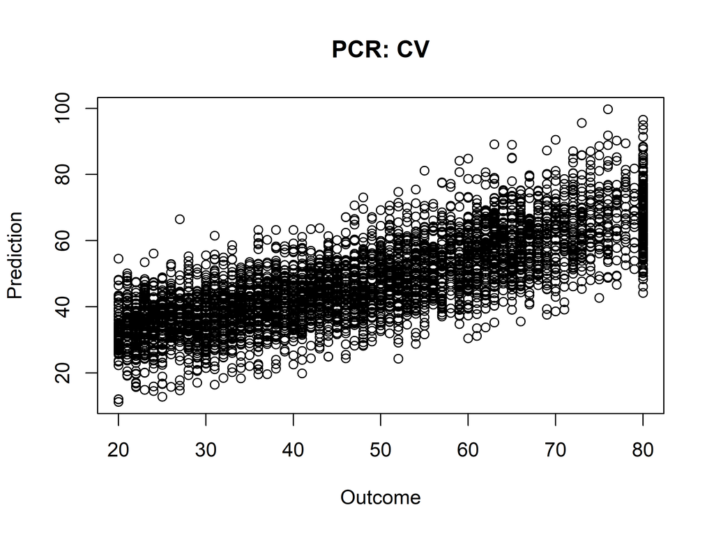

### 1.4.3 CPP

```r
#CPPlcv <- randomCV(fittingFunction = cpplsfit,
#                     trainSampleSets = PLScv$trainSamplesSets
#                    )

#CPPlbs <- predictionStats_regression(CPPlcv$medianTest,"cppls: CV")
```

### 1.4.4 LASSO

```r
LASSOcv <- randomCV(fittingFunction = LASSO_MIN,
                     trainSampleSets = PLScv$trainSamplesSets)
```

……….10 Tested: 3689 Avg. Selected: 61.1 Min Tests: 1 Max Tests: 8 Mean Tests: 2.252643 . MAD: 8.827581

……….20 Tested: 4107 Avg. Selected: 61.2 Min Tests: 1 Max Tests: 11 Mean Tests: 4.046749 . MAD: 8.815095

……….30 Tested: 4148 Avg. Selected: 60.76667 Min Tests: 1 Max Tests: 14 Mean Tests: 6.010125 . MAD: 8.826161

……….40 Tested: 4153 Avg. Selected: 60.575 Min Tests: 1 Max Tests: 17 Mean Tests: 8.003853 . MAD: 8.817307

……….50 Tested: 4153 Avg. Selected: 60.52 Min Tests: 2 Max Tests: 21 Mean Tests: 10.00482 . MAD: 8.817287

……….60 Tested: 4153 Avg. Selected: 60.41667 Min Tests: 3 Max Tests: 24 Mean Tests: 12.00578 . MAD: 8.816733

……….70 Tested: 4153 Avg. Selected: 60.35714 Min Tests: 3 Max Tests: 27 Mean Tests: 14.00674 . MAD: 8.815247

……….80 Tested: 4153 Avg. Selected: 60.325 Min Tests: 5 Max Tests: 31 Mean Tests: 16.00771 . MAD: 8.812516

……….90 Tested: 4153 Avg. Selected: 60.31111 Min Tests: 5 Max Tests: 33 Mean Tests: 18.00867 . MAD: 8.811982

……….100 Tested: 4153 Avg. Selected: 60.29 Min Tests: 8 Max Tests: 36 Mean Tests: 20.00963 . MAD: 8.813275

```r
LASSObs <- predictionStats_regression(LASSOcv$medianTest,"LASSO: CV")
```

LASSO: CV

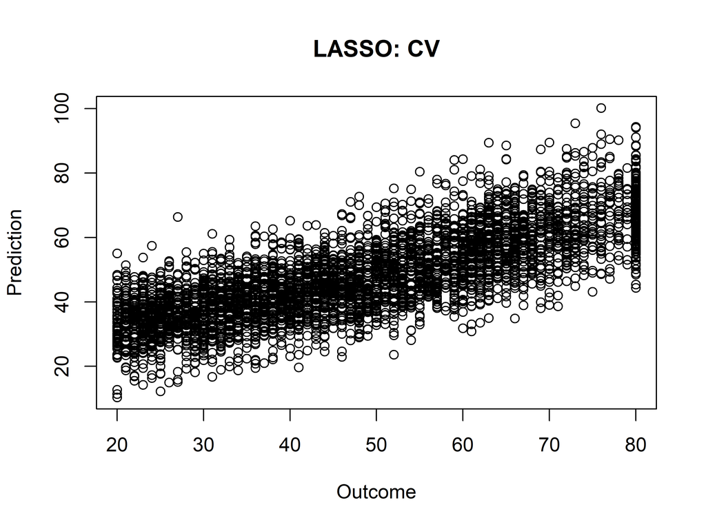

### 1.4.5 PCA LASSO

```r
PCALASSOcv <- randomCV(fittingFunction = filteredFit,
                     trainSampleSets = PLScv$trainSamplesSets,
                     fitmethod = LASSO_MIN,
                      filtermethod = NULL,
                    PCA = TRUE)
```

……….10 Tested: 3689 Avg. Selected: 50.9 Min Tests: 1 Max Tests: 8 Mean Tests: 2.252643 . MAD: 9.009237

……….20 Tested: 4107 Avg. Selected: 51.1 Min Tests: 1 Max Tests: 11 Mean Tests: 4.046749 . MAD: 9.004325

……….30 Tested: 4148 Avg. Selected: 50.86667 Min Tests: 1 Max Tests: 14 Mean Tests: 6.010125 . MAD: 9.005572

……….40 Tested: 4153 Avg. Selected: 50.8 Min Tests: 1 Max Tests: 17 Mean Tests: 8.003853 . MAD: 8.997992

……….50 Tested: 4153 Avg. Selected: 51.08 Min Tests: 2 Max Tests: 21 Mean Tests: 10.00482 . MAD: 8.998216

……….60 Tested: 4153 Avg. Selected: 50.75 Min Tests: 3 Max Tests: 24 Mean Tests: 12.00578 . MAD: 9.000117

……….70 Tested: 4153 Avg. Selected: 50.67143 Min Tests: 3 Max Tests: 27 Mean Tests: 14.00674 . MAD: 8.999955

……….80 Tested: 4153 Avg. Selected: 50.5625 Min Tests: 5 Max Tests: 31 Mean Tests: 16.00771 . MAD: 8.998562

……….90 Tested: 4153 Avg. Selected: 50.52222 Min Tests: 5 Max Tests: 33 Mean Tests: 18.00867 . MAD: 8.998846

……….100 Tested: 4153 Avg. Selected: 50.61 Min Tests: 8 Max Tests: 36 Mean Tests: 20.00963 . MAD: 8.997661

```r
PCALASSObs <- predictionStats_regression(PCALASSOcv$medianTest,"PCA-LASSO: CV")
```

PCA-LASSO: CV

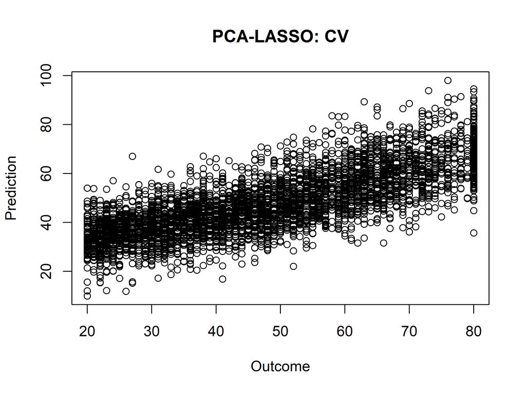

### 1.4.6 ILAA LASSO

```r
ILAALASSOcv <- randomCV(fittingFunction = filteredFit,
                     trainSampleSets = PLScv$trainSamplesSets,
                     fitmethod = LASSO_MIN,
                      filtermethod = NULL,
                    DECOR = TRUE,
                    DECOR.control=list(thr=thro,Outcome=outcome))
```

……….10 Tested: 3689 Avg. Selected: 59.7 Min Tests: 1 Max Tests: 8 Mean Tests: 2.252643 . MAD: 8.838522

……….20 Tested: 4107 Avg. Selected: 58.75 Min Tests: 1 Max Tests: 11 Mean Tests: 4.046749 . MAD: 8.828184

……….30 Tested: 4148 Avg. Selected: 57.8 Min Tests: 1 Max Tests: 14 Mean Tests: 6.010125 . MAD: 8.83877

……….40 Tested: 4153 Avg. Selected: 57.7 Min Tests: 1 Max Tests: 17 Mean Tests: 8.003853 . MAD: 8.829128

……….50 Tested: 4153 Avg. Selected: 57.6 Min Tests: 2 Max Tests: 21 Mean Tests: 10.00482 . MAD: 8.828757

……….60 Tested: 4153 Avg. Selected: 57.5 Min Tests: 3 Max Tests: 24 Mean Tests: 12.00578 . MAD: 8.826154

……….70 Tested: 4153 Avg. Selected: 57.67143 Min Tests: 3 Max Tests: 27 Mean Tests: 14.00674 . MAD: 8.825954

……….80 Tested: 4153 Avg. Selected: 57.6125 Min Tests: 5 Max Tests: 31 Mean Tests: 16.00771 . MAD: 8.825373

……….90 Tested: 4153 Avg. Selected: 57.52222 Min Tests: 5 Max Tests: 33 Mean Tests: 18.00867 . MAD: 8.822633

……….100 Tested: 4153 Avg. Selected: 57.51 Min Tests: 8 Max Tests: 36 Mean Tests: 20.00963 . MAD: 8.822959

```r
ILAALASSObs <- predictionStats_regression(ILAALASSOcv$medianTest,"ILLA-LASSO: CV")
```

ILLA-LASSO: CV

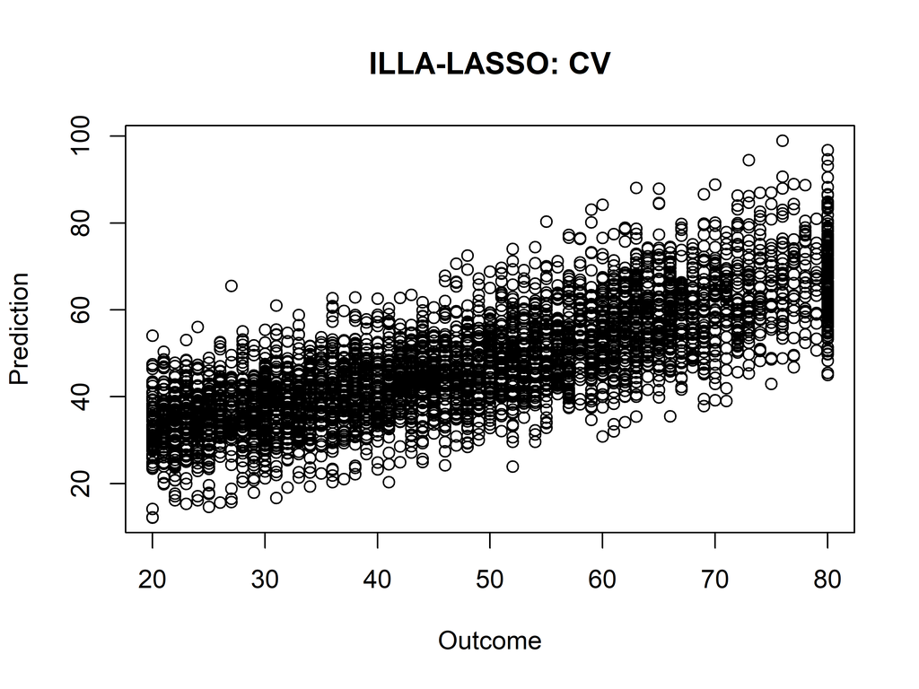

### 1.4.7 ENET

```r
ENETcv <- randomCV(fittingFunction = GLMNET_ELASTICNET_MIN,
                     trainSampleSets = PLScv$trainSamplesSets)
```

……….10 Tested: 3689 Avg. Selected: 64 Min Tests: 1 Max Tests: 8 Mean Tests: 2.252643 . MAD: 9.068167

……….20 Tested: 4107 Avg. Selected: 64 Min Tests: 1 Max Tests: 11 Mean Tests: 4.046749 . MAD: 9.052629

……….30 Tested: 4148 Avg. Selected: 64 Min Tests: 1 Max Tests: 14 Mean Tests: 6.010125 . MAD: 9.052139

……….40 Tested: 4153 Avg. Selected: 64 Min Tests: 1 Max Tests: 17 Mean Tests: 8.003853 . MAD: 9.047483

……….50 Tested: 4153 Avg. Selected: 63.98 Min Tests: 2 Max Tests: 21 Mean Tests: 10.00482 . MAD: 9.049438

……….60 Tested: 4153 Avg. Selected: 63.95 Min Tests: 3 Max Tests: 24 Mean Tests: 12.00578 . MAD: 9.047091

……….70 Tested: 4153 Avg. Selected: 63.95714 Min Tests: 3 Max Tests: 27 Mean Tests: 14.00674 . MAD: 9.046366

……….80 Tested: 4153 Avg. Selected: 63.95 Min Tests: 5 Max Tests: 31 Mean Tests: 16.00771 . MAD: 9.046963

……….90 Tested: 4153 Avg. Selected: 63.95556 Min Tests: 5 Max Tests: 33 Mean Tests: 18.00867 . MAD: 9.045746

……….100 Tested: 4153 Avg. Selected: 63.96 Min Tests: 8 Max Tests: 36 Mean Tests: 20.00963 . MAD: 9.045929

```r
ENETbs <- predictionStats_regression(ENETcv$medianTest,"ENET: CV")
```

ENET: CV

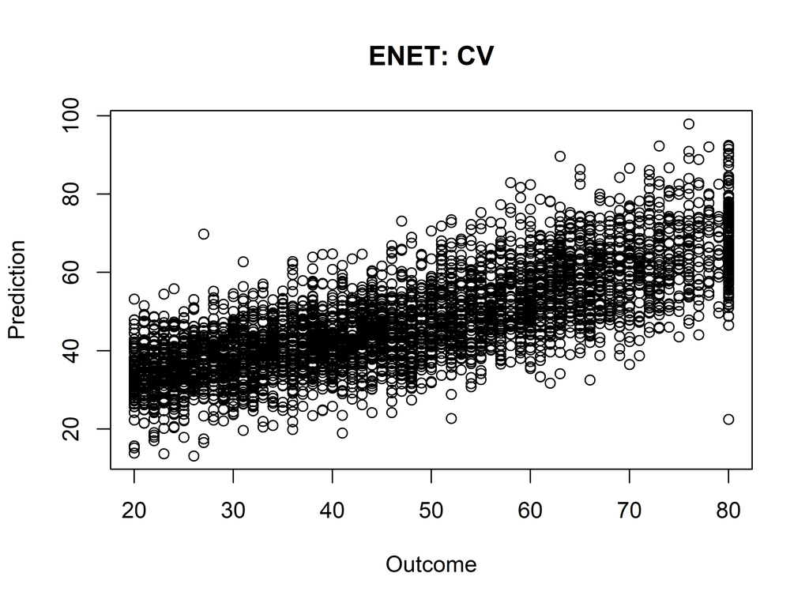

### 1.4.8 ILAAA ENET

```r
ILAAENETcv <- randomCV(fittingFunction = filteredFit,
                     trainSampleSets = PLScv$trainSamplesSets,
                     fitmethod = GLMNET_ELASTICNET_MIN,
                      filtermethod = NULL,
                    DECOR = TRUE,
                    DECOR.control=list(thr=thro,Outcome=outcome))
```

……….10 Tested: 3689 Avg. Selected: 63.9 Min Tests: 1 Max Tests: 8 Mean Tests: 2.252643 . MAD: 8.870521

……….20 Tested: 4107 Avg. Selected: 63.85 Min Tests: 1 Max Tests: 11 Mean Tests: 4.046749 . MAD: 8.859512

……….30 Tested: 4148 Avg. Selected: 63.86667 Min Tests: 1 Max Tests: 14 Mean Tests: 6.010125 . MAD: 8.865171

……….40 Tested: 4153 Avg. Selected: 63.875 Min Tests: 1 Max Tests: 17 Mean Tests: 8.003853 . MAD: 8.857912

……….50 Tested: 4153 Avg. Selected: 63.9 Min Tests: 2 Max Tests: 21 Mean Tests: 10.00482 . MAD: 8.856529

……….60 Tested: 4153 Avg. Selected: 63.88333 Min Tests: 3 Max Tests: 24 Mean Tests: 12.00578 . MAD: 8.855968

……….70 Tested: 4153 Avg. Selected: 63.9 Min Tests: 3 Max Tests: 27 Mean Tests: 14.00674 . MAD: 8.855824

……….80 Tested: 4153 Avg. Selected: 63.8875 Min Tests: 5 Max Tests: 31 Mean Tests: 16.00771 . MAD: 8.854934

……….90 Tested: 4153 Avg. Selected: 63.9 Min Tests: 5 Max Tests: 33 Mean Tests: 18.00867 . MAD: 8.852129

……….100 Tested: 4153 Avg. Selected: 63.9 Min Tests: 8 Max Tests: 36 Mean Tests: 20.00963 . MAD: 8.851234

```r
ILAAENETbs <- predictionStats_regression(ILAAENETcv$medianTest,"ILLA-ENET: CV")
```

ILLA-ENET: CV

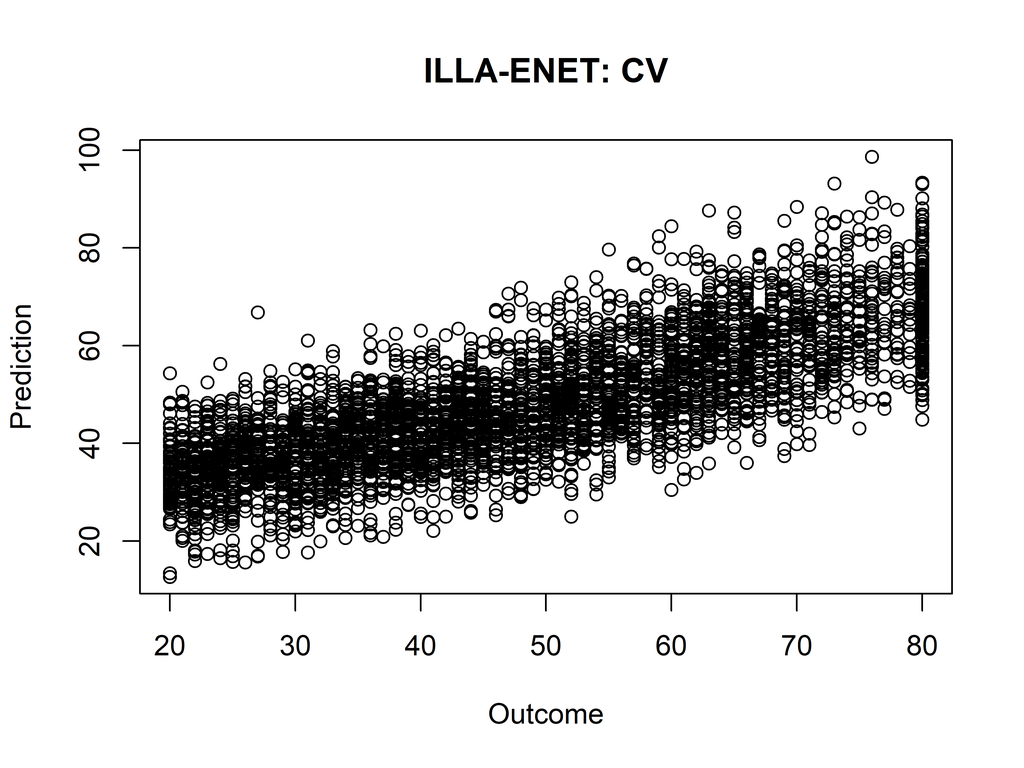

## 1.5 The Reports

```r
par(op)
RMSTABLE <- rbind(
                  PLSbs$RMSEci,
                  PCbs$RMSEci,
#                  CPPlbs$RMSEci,
                  LASSObs$RMSEci,
                  PCALASSObs$RMSEci,
                  ILAALASSObs$RMSEci,
                  ENETbs$RMSEci,
                  ILAAENETbs$RMSEci
                  )
colnames(RMSTABLE) <- c("Median","Lower","Upper")
#rownames(RMSTABLE) <- c("PLSR","PCR","CPP",
#                        "LASSO","PCA-LASSO","ILAA-LASSO","ENET","ILAA-ENET")

rownames(RMSTABLE) <- c("PLSR","PCR",
                        "LASSO","PCA-LASSO","ILAA-LASSO",
                        "ENET","ILAA-ENET")

pander::pander(RMSTABLE)
```

|  | Median | Lower | Upper |
| --- | --- | --- | --- |
| **PLSR** | 10.9 | 10.7 | 11.1 |
| **PCR** | 10.9 | 10.7 | 11.1 |
| **LASSO** | 10.9 | 10.7 | 11.1 |
| **PCA-LASSO** | 11.1 | 10.9 | 11.3 |
| **ILAA-LASSO** | 10.9 | 10.7 | 11.1 |
| **ENET** | 11.1 | 10.9 | 11.4 |
| **ILAA-ENET** | 10.9 | 10.7 | 11.1 |

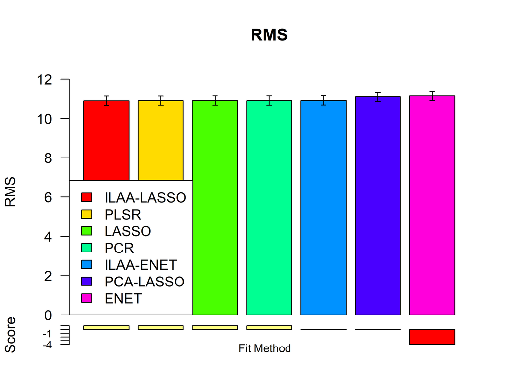

```r
themethod <- rownames(RMSTABLE)
thesets <- c("Fit Method")
pRMS <- barPlotCiError(RMSTABLE,
               "RMS",
               thesets=thesets,
               themethod=themethod,
               main="RMS",
               angle=0,
               offsets=c(0.1,1.0),
               scoreDirection="<",args.legend=list(x="bottomleft"),
               col=rainbow(length(themethod)))

par(op)
```

```r
MADTABLE <- rbind(
                  PLSbs$MAEci,
                  PCbs$MAEci,
#                  CPPlbs$MAEci,
                  LASSObs$MAEci,
                  PCALASSObs$MAEci,
                  ILAALASSObs$MAEci,
                  ENETbs$MAEci,
                  ILAAENETbs$MAEci
                  )


colnames(MADTABLE) <- colnames(RMSTABLE)
rownames(MADTABLE) <- rownames(RMSTABLE)

pander::pander(MADTABLE)
```

|  | Median | Lower | Upper |
| --- | --- | --- | --- |
| **PLSR** | 8.82 | 8.63 | 9.02 |
| **PCR** | 8.82 | 8.63 | 9.02 |
| **LASSO** | 8.81 | 8.62 | 9.01 |
| **PCA-LASSO** | 9.00 | 8.80 | 9.20 |
| **ILAA-LASSO** | 8.83 | 8.63 | 9.01 |
| **ENET** | 9.05 | 8.85 | 9.24 |
| **ILAA-ENET** | 8.85 | 8.66 | 9.05 |

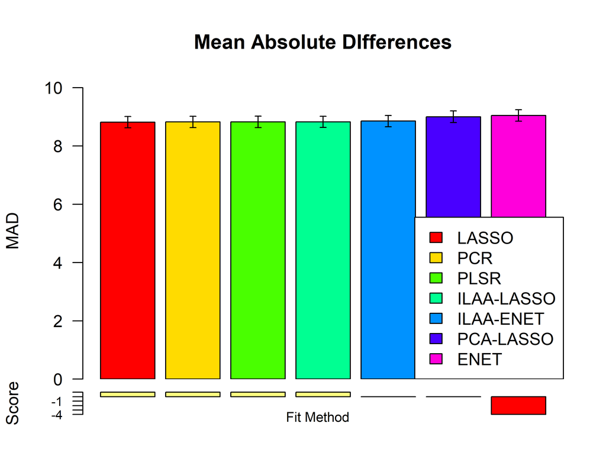

```r
pber <- barPlotCiError(MADTABLE,
               "MAD",
               thesets=thesets,
               themethod=themethod,
               main="Mean Absolute DIfferences",
               angle=0,
               offsets=c(0.1,0.5),
               scoreDirection="<",args.legend=list(x="bottomright"),
               col=rainbow(length(themethod))
               )
```

```r
PearsonTABLE <- rbind(
                  PLSbs$corci,
                  PCbs$corci,
#                  CPPlbs$corci,
                  LASSObs$corci,
                  PCALASSObs$corci,
                  ILAALASSObs$corci,
                  ENETbs$corci,
                  ILAAENETbs$corci
                  )


colnames(PearsonTABLE) <- colnames(RMSTABLE)
rownames(PearsonTABLE) <- rownames(RMSTABLE)

pander::pander(PearsonTABLE)
```

|  | Median | Lower | Upper |
| --- | --- | --- | --- |
| **PLSR** | 0.775 | 0.763 | 0.787 |
| **PCR** | 0.775 | 0.763 | 0.787 |
| **LASSO** | 0.775 | 0.763 | 0.787 |
| **PCA-LASSO** | 0.766 | 0.753 | 0.778 |
| **ILAA-LASSO** | 0.776 | 0.763 | 0.787 |
| **ENET** | 0.764 | 0.751 | 0.776 |
| **ILAA-ENET** | 0.775 | 0.763 | 0.787 |

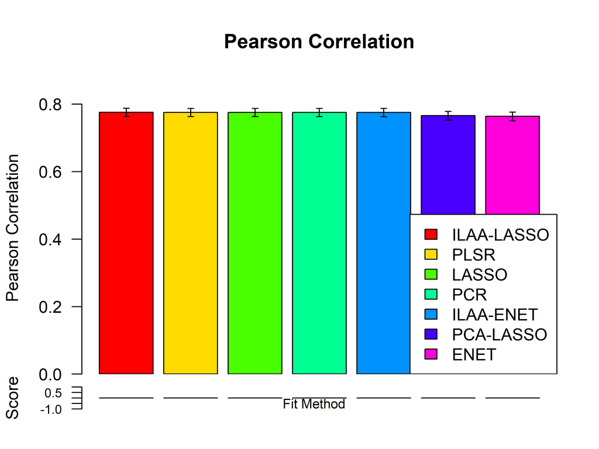

```r
pber <- barPlotCiError(PearsonTABLE,
               "Pearson Correlation",
               thesets=thesets,
               themethod=themethod,
               main="Pearson Correlation",
               angle=0,
               offsets=c(0.1,0.5),
               scoreDirection=">",args.legend=list(x="bottomright"),
               col=rainbow(length(themethod))
               )
```

### 1.5.1 Saving ALL

```r
save.image(paste("SOTACV_analyiss",studyName,".RData",sep="_"))
```